# Detection of batch effects in cytometry data

Christina Bligaard Pedersen

February 18, 2021

This vignette will demonstrate the use of the `detect_batch_effect` function of cyCombine.

For an introduction to the `detect_batch_effect_express` function, please refer to the [one-panel CyTOF example](https://biosurf.org/cyCombine_CyTOF_1panel.html).

The function will be demonstrated using data from a study of CLL patients and healthy donors at the Dana-Farber Cancer Institute (DFCI). The protein expression was quantified using mass cytometry for 109 samples (20 healthy donors). The data was run in seven batches.

# Pre-processing data

We start by loading some packages.

```r
library(cyCombine)
library(tidyverse)
```

We are now ready to load the CyTOF data. We have set up a panel file in csv format, so the correct information is extractable from there.

```r
# Directory with raw .fcs files
data_dir <- "dfci2_2"

# Panel and reading data
panel <- read_csv(paste0(data_dir, "/panel2.csv"))
```

We then progress with reading the CyTOF dataset and converting it to a tibble format, which is easy to process. We use cofactor = 5 (default) and derandomization (default) in this case.

```r
# Extracting the markers
markers <- panel %>%
  filter(Type != "none") %>%
  pull(Marker) %>%
  str_remove_all("[ _-]")

# Preparing the expression data
dfci <- prepare_data(data_dir = data_dir,
                     metadata = paste0(data_dir, "/metadata.csv"),
                     filename_col = "FCS_name",
                     batch_ids = "Batch",
                     condition = "Set",
                     derand = TRUE,
                     markers = markers,
                     down_sample = FALSE)
```

```
Reading 109 files to a flowSet..
```

```
Extracting expression data..
```

```
Your flowset is now converted into a dataframe.
```

```
Transforming data using asinh with a cofactor of 5..
```

```
Done!
```

# Checking for batch effects

In some experiments one may already know that batch effects exist. Maybe a marker was clearly overstained in one batch or a different antibody for the same protein was used in some batches. However, sometimes it is not known if batch effects - beyond those accounted for by bead normalization - are present. Such hidden technical variation can, depending on its severity, be detrimental to a biological analysis.

Accordingly, one should always inspect their data for batch effects before proceeding to clustering and other analysis steps. Here, we will see what can be learned from cyCombine’s `detect_batch_effect` function.

```r
detect_batch_effect(dfci,
                    batch_col = 'batch',
                    out_dir = paste0(data_dir, '/batch_effect_check'),
                    seed = 434,
                    name = 'DFCI panel 2 data')
```

```
Determining new cell type labels using SOM:
```

```
Creating SOM grid..
```

```
Scaling expression data..
```

```
There are 3 markers, which appear to be outliers in a single batch:
```

```
CD14, FCeR1a, TGFB1
```

```
There are 1 clusters, in which a single cluster is strongly over- or underrepresented.
```

```
The cluster percentages for each batch in cluster 10 are:
```

```
1 = 0.69 %, 2 = 1.98 %, 3 = 0.69 %, 4 = 0.7 %, 5 = 0.67 %, 6 = 0.92 %, 7 = 0.78 %
```

```
The cluster expresses IL1RA, CD56, JAK1, CD11b, CD11c, CD45RA, CD16, TGFBR2, CD8, DR3.
```

```
Making UMAP plots for up to 50,000 cells.
```

```
Saved UMAP plot for batches and labels here: dfci2_2/batch_effect_check as UMAP_batches_labels.png.
```

```
Saved UMAP plot colored by each marker in directory: dfci2_2/batch_effect_check/UMAP_markers.
```

```
Done!
```

In the printed output, we get some pointers to potential problems with batch effects. It points to three markers, which seem affected by batch effects. Furthermore, it also performs a clustering (SOM) and identifies that one of the obtained clusters has a significant over-representation in batch 2. This cluster appears to be a CD16+ NK cell cluster.

Additionally, the function provides a lot of UMAP plots, which are saved in the directory specified by `out_dir`. The first plot is the UMAP_batches_labels plot, which shows a UMAP for up to 50,000 cells across the batches in the dataset. One UMAP is colored by batch - another by SOM node (=cluster). While this might be tricky to decipher, it can be a good starting point for understanding the potential batch effects. It further generates the same UMAP colored by each protein marker in the dataset.

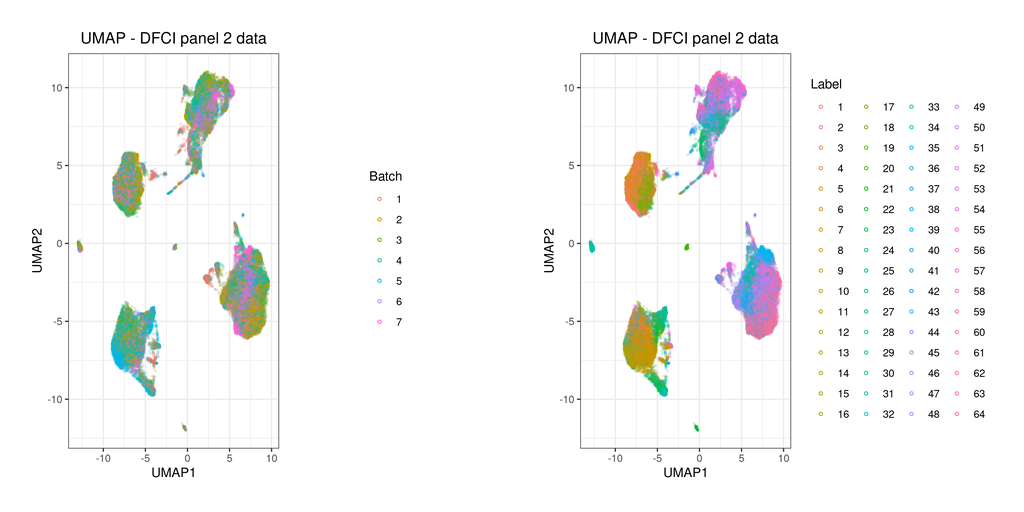

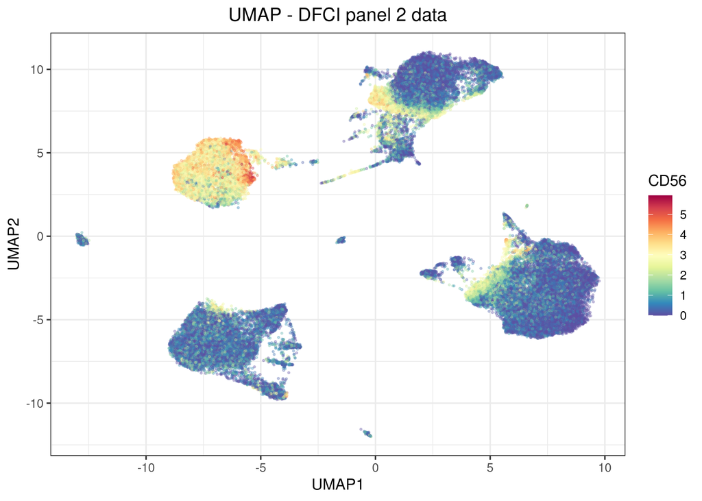

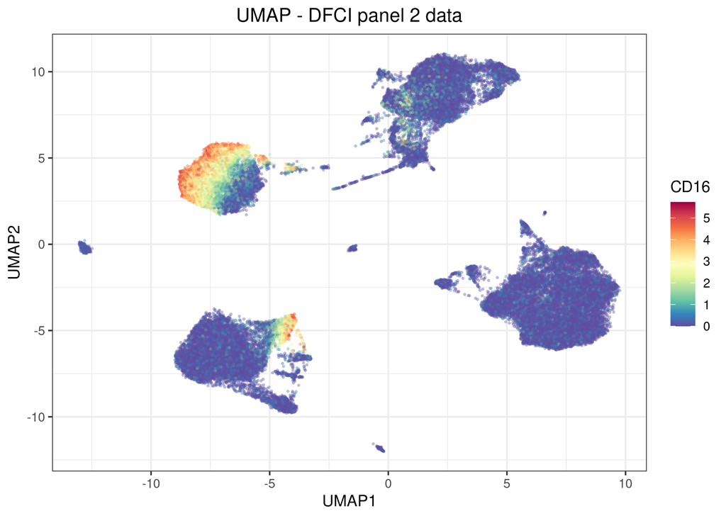

It is recommended to also call the `detect_batch_effect_express` function to invesigate the output of that function and relate it to the results generated here.

Contact